# 수업강의자료-COVID19 dataset in Korea

## 1. 라이브러리 가져오기

본 분석에 필요한 라이브러리는 Numpy, Pandas, Datetime, Matplotlib, Seaborn, 그리고 Plotly 입니다.

- Numpy: 파이썬과 함께 데이터의 다양한 연산을 도와주는 필수 라이브러리 입니다.
- Pandas: 파이썬을 사용하여 데이터를 수집하고 분석 및 가시화할 수 있는 라이브러리 입니다.
- Datetime: 파이썬에서 날짜와 시간을 연산하는데 유용한 함수를 제공하는 라이브러리 입니다.
- Matplotlib: 파이썬 결과물을 출력하는 필수 라이브러리 입니다.
- Seaborn: 파이썬 결과물을 출력하는데 Matplotlib보다 좀더 가시화를 강화한 라이브러리 입니다.
- Plotly: Seaborn과 같이 Matplotlib보다 좀더 가시화를 강화한 라이브러리 입니다.

```python
import numpy as np
import pandas as pd
import matplotlib.pyplot as plt
import seaborn as sns
```

## 2. 데이터 불러오기

우선 Pandas 라이브러리를 이용해서 csv 형태의 데이터를 불러오도록 하겠습니다.

```python
# data_time    = pd.read_csv('Data0306/time.csv')
# data_route   = pd.read_csv('Data0306/route.csv')
data_patient = pd.read_csv('Data0306/patient.csv')
```

Pandas에서 제공하는 head() 함수를 이용하여 patient 데이터가 잘 불러왔는지 확인하겠습니다.

```python
data_patient.head()
```

|  | id | gender | birth_year | country | region | group | infection_reason | infection_order | infected_by | contact_number | confirmed_date | released_date | deceased_date | state |
| --- | --- | --- | --- | --- | --- | --- | --- | --- | --- | --- | --- | --- | --- | --- |
| 0 | 1.0 | female | 1984.0 | China | filtered at airport | NaN | visit to Wuhan | 1.0 | NaN | 45.0 | 2020/01/20 | 2020/02/06 | NaN | released |
| 1 | 2.0 | male | 1964.0 | Korea | filtered at airport | NaN | visit to Wuhan | 1.0 | NaN | 75.0 | 2020/01/24 | 2020/02/05 | NaN | released |
| 2 | 3.0 | male | 1966.0 | Korea | capital area | NaN | visit to Wuhan | 1.0 | NaN | 16.0 | 2020/01/26 | 2020/02/12 | NaN | released |
| 3 | 4.0 | male | 1964.0 | Korea | capital area | NaN | visit to Wuhan | 1.0 | NaN | 95.0 | 2020/01/27 | 2020/02/09 | NaN | released |
| 4 | 5.0 | male | 1987.0 | Korea | capital area | NaN | visit to Wuhan | 1.0 | NaN | 31.0 | 2020/01/30 | 2020/03/02 | NaN | released |

## 3. 데이터 개요

불러온 patient.csv 파일잠시 살펴보도록 하겠습니다. info() 함수를 사용시 아래과 같은 결과가 나타납니다. 총 데이터는 6,285개이고, 14개의 항목이 제시되어 있습니다. 그 대부분의 데이터는 아쉽게도 없는 값들이 많이 있습니다. 예를 들어 id, country, confirmed_date, 그리고 state 의 경우는 6,000개 이상의 값이 있는 반면에 그 외 항목은 대부분이 null 값으로 되어 있습니다.

```python
data_patient.info()
```

```
<class 'pandas.core.frame.DataFrame'>
RangeIndex: 6285 entries, 0 to 6284
Data columns (total 14 columns):
 #   Column            Non-Null Count  Dtype
---  ------            --------------  -----
 0   id                6284 non-null   float64
 1   gender            421 non-null    object
 2   birth_year        408 non-null    float64
 3   country           6283 non-null   object
 4   region            409 non-null    object
 5   group             83 non-null     object
 6   infection_reason  146 non-null    object
 7   infection_order   35 non-null     float64
 8   infected_by       70 non-null     float64
 9   contact_number    50 non-null     float64
 10  confirmed_date    6284 non-null   object
 11  released_date     38 non-null     object
 12  deceased_date     23 non-null     object
 13  state             6284 non-null   object
dtypes: float64(5), object(9)
memory usage: 687.5+ KB
```

```python
data_patient.isna().sum()
```

```
id                     1
gender              5864
birth_year          5877
country                2
region              5876
group               6202
infection_reason    6139
infection_order     6250
infected_by         6215
contact_number      6235
confirmed_date         1
released_date       6247
deceased_date       6262
state                  1
dtype: int64
```

## 4. 일자별 확진자 추세

2020년 1월 20일부터 시작된 COVID-19 확진자의 일자별 추세를 한번 살펴보도록 하겠습니다. 이것과 관련된 데이터는 time.csv로 이것을 Pandas를 사용하여 불러 오도록 하겠습니다. time.csv는 11개의 항목이 존재하며, 각각의 항목의 의미는 다음과 같습니다.

- date: 일자를 의미합니다. 1월 20일부터 3월5일까지 데이터입니다.
- acc_test : 누적된 검사자
- acc_negative : 누적 음성 확진자
- acc_confirmed : 누적 양성 확진자
- acc_released : 누적 격리해제자
- acc_deceased : 누적 사망자
- new_test : 신규 검사자
- new_negative : 신규 음성 확진자
- new_confirmend: 신규 양성 확진자
- new_released : 신규 격리해제자
- new_deceased : 신규 사망자

```python
data_time = pd.read_csv('Data0306/time.csv')
data_time.head()
```

|  | date | acc_test | acc_negative | acc_confirmed | acc_released | acc_deceased | new_test | new_negative | new_confirmed | new_released | new_deceased |
| --- | --- | --- | --- | --- | --- | --- | --- | --- | --- | --- | --- |
| 0 | 2020/01/20 | 1 | 0 | 1 | 0 | 0 | 1 | 0 | 1 | 0 | 0 |
| 1 | 2020/01/21 | 1 | 0 | 1 | 0 | 0 | 0 | 0 | 0 | 0 | 0 |
| 2 | 2020/01/22 | 4 | 3 | 1 | 0 | 0 | 3 | 3 | 0 | 0 | 0 |
| 3 | 2020/01/23 | 22 | 21 | 1 | 0 | 0 | 18 | 18 | 0 | 0 | 0 |
| 4 | 2020/01/24 | 27 | 25 | 2 | 0 | 0 | 5 | 4 | 1 | 0 | 0 |

### 4.1 누적 확진자 추세

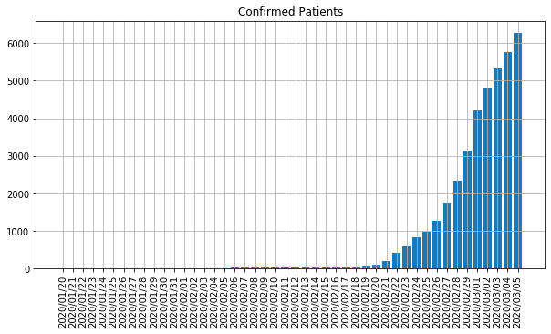

```python
plt.figure(figsize=(10,5))
plt.bar(data_time['date'], data_time['acc_confirmed'])
plt.xticks(rotation=90);
plt.title('Confirmed Patients')
plt.grid()
# plt.locator_params(axis='x', nbins=10)
```

### 4.2 일자별 확진자 및 누적 확진자 추세

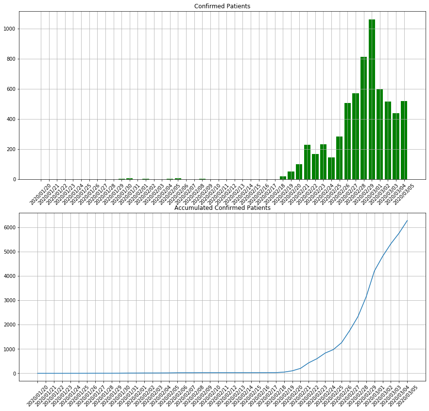

```python
plt.figure(figsize=(15,14))
plt.subplot(2,1,1)
plt.bar(data_time['date'], data_time['new_confirmed'], color='g')
plt.xticks(rotation=45);
plt.title('Confirmed Patients')
plt.grid()


plt.subplot(2,1,2)
plt.plot(data_time['date'], data_time['acc_confirmed'])
plt.xticks(rotation=45);
plt.grid()
plt.title('Accumulated Confirmed Patients')
```

### 4.3 누적 격리해제자 및 누적 사망자 추세

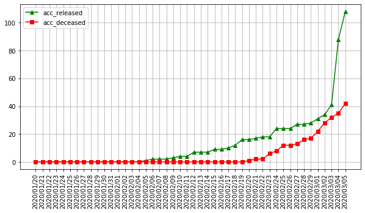

```python
plt.figure(figsize=(10,5))
plt.plot(data_time['date'], data_time['acc_released'], 'g-^', label='acc_released')
plt.plot(data_time['date'], data_time['acc_deceased'], 'r-s', label='acc_deceased')
plt.xticks(rotation=90)
plt.legend(loc='best')
plt.grid()
```

### 4.4 격리해제자 대비 사망자 비율 추세

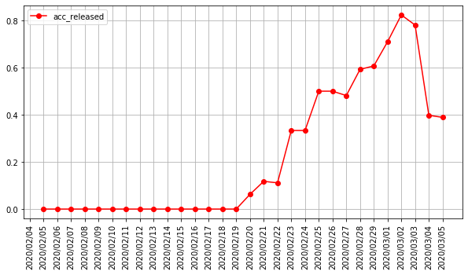

```python
data_time['ratio'] = (data_time['acc_released'] - data_time['acc_deceased'])/data_time['acc_released']
data_time['ratio2'] = data_time['acc_deceased']/data_time['acc_released']

plt.figure(figsize=(10,5))
# plt.plot(data_time['date'], data_time['ratio'], 'g-^', label='acc_released')
plt.plot(data_time['date'], data_time['ratio2'], 'r-o', label='acc_released')



plt.xticks(rotation=90)
plt.legend(loc='best')
plt.grid()
```

## 5. 지역별 환자분포

이번에는 지역별로 환자분포가 어떻게 되는지 살펴보도록 하겠습니다. 이것을 위해 route.csv 파일을 불러오겠습니다. 이 파일은 7개의 항목의 데이터가 존재하고 세분적인 내용은 다음과 같습니다.

- id: 환자 id
- date: 일자
- provice: 지역
- city: 도시
- visit: 방문장소 예) 공항, 병원 등
- lattitude: 위치 위도
- longitude: 위치 경도

```python
import pandas as pd
data_route   = pd.read_csv('Data0306/route.csv')
data_route.head()
```

|  | id | date | province | city | visit | latitude | longitude |
| --- | --- | --- | --- | --- | --- | --- | --- |
| 0 | 1 | 2020-01-19 | Incheon | Jung-gu | airport | 37.460459 | 126.440680 |
| 1 | 1 | 2020-01-20 | Incheon | Seo-gu | hospital_isolated | 37.478832 | 126.668558 |
| 2 | 2 | 2020-01-22 | Gyeonggi-do | Gimpo-si | airport | 37.562143 | 126.801884 |
| 3 | 2 | 2020-01-23 | Seoul | Jung-gu | hospital_isolated | 37.567454 | 127.005627 |
| 4 | 3 | 2020-01-20 | Incheon | Jung-gu | airport | 37.460459 | 126.440680 |

### 5.1 도시별 환자수 분포

이번에는 결과의 가시화를 Matplotlib가 아닌 Pandas를 활용해 보도록 하겠습니다.

```python
data_route.city.value_counts()
```

```
Jung-gu            14
Gangnam-gu          8
Seongnam-si         7
Bucheon-si          7
Goyang-si           7
Jungnang-gu         7
Guri-si             6
Jongno-gu           5
Suwon-si            5
Gangneung-si        5
Dong-gu             4
Songpa-gu           4
Gunsan-si           4
Gimpo-si            3
Gwangsan-gu         2
Seongbuk-gu         2
Pyeongtaek-si       2
Muan-gun            1
Gwangjin-gu         1
Seocho-gu           1
Seo-gu              1
Gunpo-si            1
Suseong-gu          1
Buk-gu              1
Yeonsu-gu           1
Yeongdeungpo-gu     1
Seongdong-gu        1
Name: city, dtype: int64
```

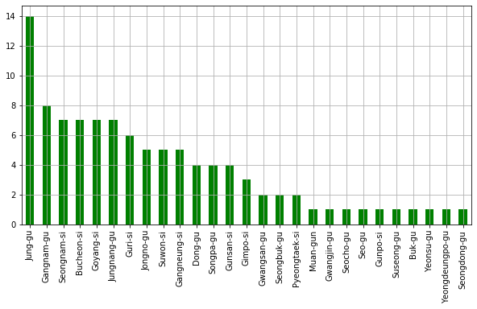

```python
plt.figure(figsize=(10,5))
data_route.city.value_counts().plot.bar(color='g')
plt.grid()
```

### 5.2 지역별 환자수 분포

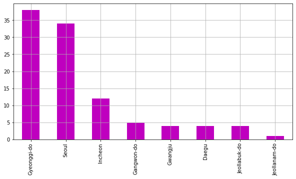

```python
plt.figure(figsize=(10,5))
data_route.province.value_counts().plot.bar(color='m')
plt.grid()
```

### 5.3 확진자 방문장소 비율

```
hospital_isolated    19
restaurant           13
airport              13
hospital             10
clinic                8
train_station         7
etc                   7
store                 5
market                5
hair_salon            3
hotel                 3
movie_theater         3
company               2
cafe                  1
church                1
office                1
bus_terminal          1
Name: visit, dtype: int64
```

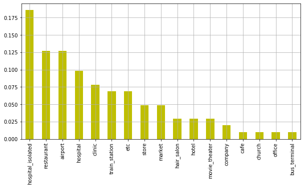

```python
print(data_route.visit.value_counts())
temp = data_route.visit.value_counts()/data_route.visit.value_counts().sum()


plt.figure(figsize=(10,5))
temp.plot.bar(color='y')
plt.grid()
```

### 5.4 확진자 위치 가시화

대한민국 지도에 확진자 위치를 가시화하고자 합니다. 이를 위해선 folium 이라는 라이브러리가 필요합니다. 다음과 같이 라이브러리를 설치하기 바랍니다. 현재 셀에 입력할 명령어는 아래와 같고 이를 실행하면 설치하는 과정이 나타나게 됩니다.

> !pip install folium

설치가 완료되었으면, 방금 설치한 라이브러리가 커널에 적용될 수 있도록, Kernel을 재부팅을 합니다. 탭의 Kernel을 선택하고 Restart & Run All을 선택합니다.

```python
import folium
southkorea_map = folium.Map(location=[36.55,126.983333 ], zoom_start=7,tiles='Stamen Toner')

for lat, lon,city in zip(data_route['latitude'], data_route['longitude'],data_route['city']):
    folium.CircleMarker([lat, lon],
                        radius=5,
                        color='red',
                      popup =('City: ' + str(city) + '<br>'),
                        fill_color='red',
                        fill_opacity=0.7 ).add_to(southkorea_map)
southkorea_map
```

[interactive chart not shown]

## 6. 확진자 세부 분석

이번에는 확진자에 대한 정보를 기초로 몇가지 분석을 진행해 보겠습니다. patient.csv 파일을 사용합니다. 총 14가지 항목이 존재하며, 각 항목의 세부적인 내용은 다름과 같습니다.

- id: 환자 ID
- gender: 성별
- birth_year: 태어난 연도
- country: 국적
- region: 지역
- group: 확진 그룹
- infection_reason: 감염원인
- infection_order: 감염 차수
- infected_by: 감염전달 확진자 ID
- contact_number : 접촉 인원수
- confirmed_date: 확진판정 날짜
- released_date: 격리해제 날짜
- deceased_date: 사망 날짜
- state: 환자상태 예) 격리, 격리해제, 사망

```python
import pandas as pd
data_patient = pd.read_csv('Data0306/patient.csv')
data_patient.head()
```

|  | id | gender | birth_year | country | region | group | infection_reason | infection_order | infected_by | contact_number | confirmed_date | released_date | deceased_date | state |
| --- | --- | --- | --- | --- | --- | --- | --- | --- | --- | --- | --- | --- | --- | --- |
| 0 | 1.0 | female | 1984.0 | China | filtered at airport | NaN | visit to Wuhan | 1.0 | NaN | 45.0 | 2020/01/20 | 2020/02/06 | NaN | released |
| 1 | 2.0 | male | 1964.0 | Korea | filtered at airport | NaN | visit to Wuhan | 1.0 | NaN | 75.0 | 2020/01/24 | 2020/02/05 | NaN | released |
| 2 | 3.0 | male | 1966.0 | Korea | capital area | NaN | visit to Wuhan | 1.0 | NaN | 16.0 | 2020/01/26 | 2020/02/12 | NaN | released |
| 3 | 4.0 | male | 1964.0 | Korea | capital area | NaN | visit to Wuhan | 1.0 | NaN | 95.0 | 2020/01/27 | 2020/02/09 | NaN | released |
| 4 | 5.0 | male | 1987.0 | Korea | capital area | NaN | visit to Wuhan | 1.0 | NaN | 31.0 | 2020/01/30 | 2020/03/02 | NaN | released |

### 6.1 확진자 상태분석 - 격리, 격리해제, 사망

```python
# 전체 환자수
num_patient_all = data_patient.shape[0]

# data_patient.loc[data_patient['state'] == 'deceased']

# 격리환자수
num_patient_isolated = data_patient.loc[data_patient['state'] == 'isolated'].shape[0]

# 격리해제 환자수
num_patient_released = data_patient.loc[data_patient['state'] == 'released'].shape[0]

# 사망자수
num_patient_deceased = data_patient.loc[data_patient['state'] == 'deceased'].shape[0]

print('All number of patients:', num_patient_all)
print('Number of the isolated:', num_patient_isolated)
print('Number of the released:', num_patient_released)
print('Number of the deceased:', num_patient_deceased)
```

```
All number of patients: 6285
Number of the isolated: 6221
Number of the released: 40
Number of the deceased: 23
```

환자상태별 퍼센트지를 계산해보겠습니다.

```python
print('Percentages of the isolated: %.4f percents' % ((num_patient_isolated/num_patient_all*100)))
print('Percentages of the released: %.4f%%' % ((num_patient_released/num_patient_all*100)))
print('Percentages of the deceased: %.4f%%' % ((num_patient_deceased/num_patient_all*100)))
```

```
Percentages of the isolated: 98.9817 percents
Percentages of the released: 0.6364%
Percentages of the deceased: 0.3660%
```

### 6.2 확진자 상태 원형 그래프 가시화

```
 [Text(-1.0994544512559028, 0.03463971151123689, 'The isolated'),
 [Text(-0.5997024279577651, 0.0188943880970383, '99.00%'),
```

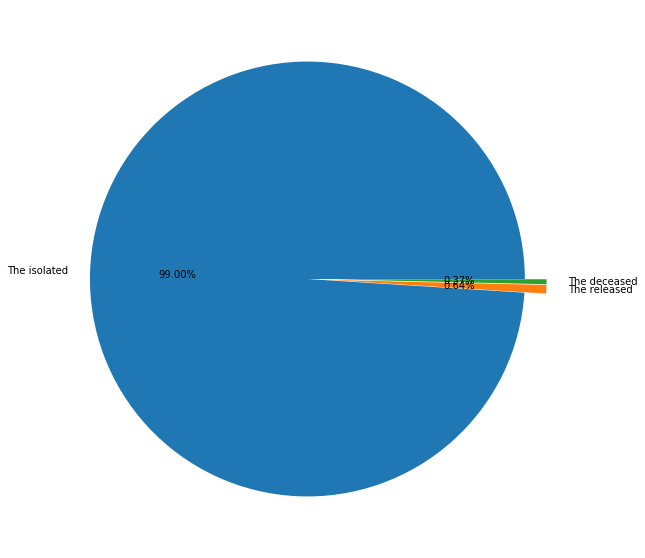

```python
labels = 'The isolated','The released','The deceased'
X = [num_patient_isolated, num_patient_released, num_patient_deceased]

plt.figure(figsize=(10,10))

plt.pie(X, labels=labels, shadow=False, autopct='%1.2f%%', explode=(0, 0.1, 0.1))
```

### 6.3 연령대별 환자분포

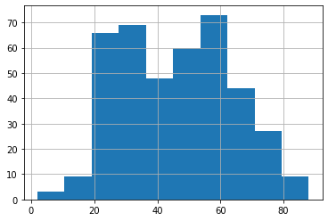

```python
# 연령 계산

data_patient['Ages'] = 2020 - data_patient['birth_year']

data_patient['Ages'].hist()
```

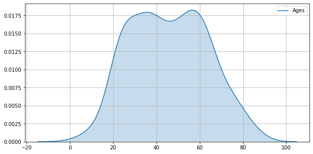

```python
import seaborn as sns

plt.figure(figsize=(10,5))
sns.kdeplot(data=data_patient['Ages'], shade=True)
plt.grid()
```

### 6.3.1 격리해제자의 연령대별 분포

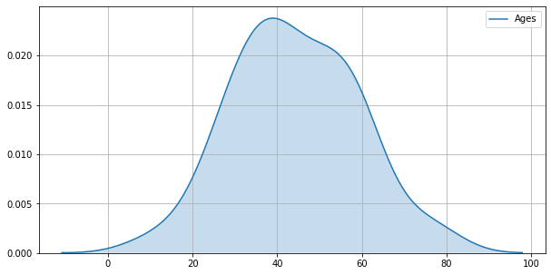

```python
The_released = data_patient[data_patient['state'] == 'released']

plt.figure(figsize=(10,5))
sns.kdeplot(data=The_released['Ages'], shade=True)
plt.grid()
```

### 6.3.2 사망자의 연령대별 분포

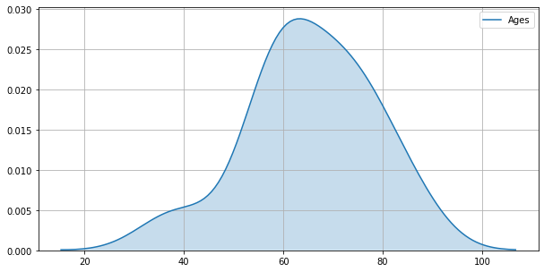

```python
The_deceased = data_patient[data_patient['state'] == 'deceased']

plt.figure(figsize=(10,5))
sns.kdeplot(data=The_deceased['Ages'], shade=True)
plt.grid()
```

### 6.3.3. 환자상태별 연령대별 분포

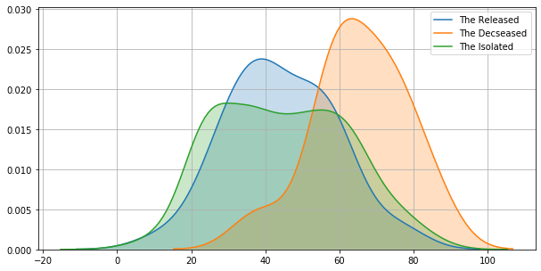

```python
The_isolated = data_patient[data_patient['state'] == 'isolated']

plt.figure(figsize=(10,5))
sns.kdeplot(data=The_released['Ages'], shade=True, label='The Released')
sns.kdeplot(data=The_deceased['Ages'], shade=True, label='The Decseased')
sns.kdeplot(data=The_isolated['Ages'], shade=True, label='The Isolated')
plt.grid()
```

### 6.4 감염원인 분포

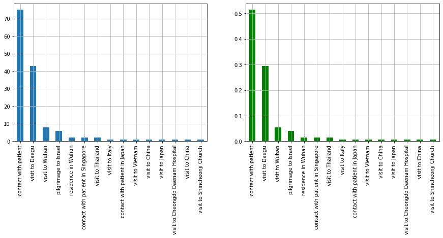

```python
plt.figure(figsize=(15,5))

plt.subplot(1,2,1)
data_patient.infection_reason.value_counts().plot.bar();
plt.grid()


# 비율
plt.subplot(1,2,2)
temp2 = data_patient.infection_reason.value_counts()/data_patient.infection_reason.value_counts().sum()
temp2.plot.bar(color='g')
plt.grid()
```

### 6.5 사망자의 감염원인 분포

```
contact with patient    1
Name: infection_reason, dtype: int64
```

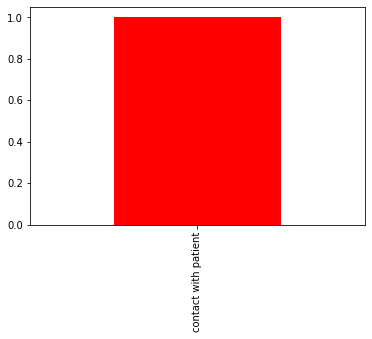

```python
The_deceased = data_patient[data_patient['state'] == 'deceased']

The_deceased['infection_reason'].value_counts().plot.bar(color='r')
print(The_deceased['infection_reason'].value_counts())
```

```
contact with patient                 16
visit to Wuhan                        8
residence in Wuhan                    2
contact with patient in Singapore     2
visit to Thailand                     1
contact with patient in Japan         1
visit to Daegu                        1
Name: infection_reason, dtype: int64
```

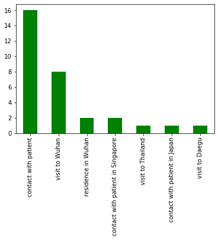

```python
The_released['infection_reason'].value_counts().plot.bar(color='g')
print( The_released['infection_reason'].value_counts())
```